# Untitled

Lucas Boyd

4/15/2022

```r
knitr::opts_chunk$set(echo = TRUE, warning = FALSE, message = FALSE)
library(here)
library(tidyverse)
library(tsibble)
library(lubridate)
library(feasts)
```

# Reading in the climate data:

The following CSVs were created using the esm_237_as2_csv_template.Rmd

```r
# MODEL OUTPUTS
# FGOAL and CESM are two different models, SSP2 and SSP5 are the different scenarios

fgoal_2 <- read_csv(here("data", "fgoal_245.csv")) %>%  # FGOAL SSP2
  mutate(year = year(date))
fgoal_5 <- read_csv(here("data", "fgoal_585.csv")) %>%  # FGOAL SSP5
  mutate(year = year(date))
cesm_2 <- read_csv(here("data", "cesm_245.csv")) %>%  # CESM SSP2
  mutate(year = year(date))
cesm_5 <- read_csv(here("data", "cesm_585.csv")) %>% # CESM SSP5
  mutate(year = year(date))



# HISTORICAL DATA

hist1 <- read_csv(here("data", "historical1.csv"))
hist2 <- read_csv(here("data", "historical2.csv"))
hist3 <- read_csv(here("data", "historical3.csv"))
hist4 <- read_csv(here("data", "historical4.csv"))

# historical data compiled 1848-2012
historical_cesm <- rbind(hist1, hist2, hist3, hist4) %>%
  mutate(year = year(date))

historical_fgoal <- read_csv(here("data", "fgoal_historical.csv"))  %>%
  mutate(year = year(date))
```

**Location Choice:** Svalbard, Norway **Latitude:** Between 76-81 **Longitude:** Between 10-30

**Introduction:** The northernmost settlement of humans on Earth is located on the island chain that contains Svalbard, Norway. This location is an archipelago between Norway and the North Pole that consists of glaciers and frozen tundra, sporting a larger population of polar bears than human inhabitants. Svalbard is an interesting place to look at for climate scenarios because of its location, and characteristics of its landscape. More than half of Svalbard’s lands are covered by glaciers, numbering over 2,000 and covering almost 60% of land area, with one of the world’s largest ice caps located on the Nordaustlandet island. Svalbard is at the end of the Gulf Stream’s path, which brings a mixture a warm and cold water to the Bering Sea, making the sea rich in aquatic life.

With Svalbard’s location and climate we would expect the future impacts of climate change to be exacerbated due to polar amplification. The northern arctic is warming at a high rate compared to the rest of the world, with Svalbard being located in the fastest warming region within the circumpolar arctic (Descamps et al., 2017). Glaciers and sea level are important aspects of climate impacts to look at in future scenarios, as they are defining characteristics of the island. In this assignment we consider surface air temperature, which provides us with an understanding of how climate change will affect the ambient temperature of the region. We can use this data to anticipate the changes in glaciers, amount of permafrost, and overall evolution of Svalbard’s ecosystems as our climate continues to change.

**SSP Choice:** We chose SSP2 because it represents a middle of the road, business as usual outcome, while SSP5 is the highest emissions outcome. These comparisons are useful because of their simplicity to translate into layman's terms.

SSP 2 Middle of the Road (Medium challenges to mitigation and adaptation) In this scenario the world follows a path in which social, economic, and technological trends do not shift markedly from historical patterns. Development and income growth proceeds unevenly, with some countries making relatively good progress while others fall short of expectations. Global and national institutions work toward but make slow progress in achieving sustainable development goals. Environmental systems experience degradation, although there are some improvements and overall the intensity of resource and energy use declines. Global population growth is moderate and levels off in the second half of the century. Income inequality persists or improves only slowly and challenges to reducing vulnerability to societal and environmental changes remain.

SSP5 Fossil-fueled Development – Taking the Highway (High challenges to mitigation, low challenges to adaptation) For this scenario, the world places increasing faith in competitive markets, innovation and participatory societies to produce rapid technological progress and development of human capital as the path to sustainable development. Global markets are increasingly integrated. There are also strong investments in health, education, and institutions to enhance human and social capital. At the same time, the push for economic and social development is coupled with the exploitation of abundant fossil fuel resources and the adoption of resource and energy intensive lifestyles around the world. All these factors lead to rapid growth of the global economy, while global population peaks and declines in the 21st century. Local environmental problems like air pollution are successfully managed. There is faith in the ability to effectively manage social and ecological systems, including by geo-engineering if necessary.

```r
# Yearly ts
fgoal_2_yearly <- fgoal_2 %>%
  group_by(year) %>%
  summarize(mean_tas = mean(average_tas_c, na.rm = TRUE)) %>%
  filter( year != 2013)

fgoal_5_yearly <- fgoal_5 %>%
  group_by(year) %>%
  summarize(mean_tas = mean(average_tas_c, na.rm = TRUE)) %>%
  filter( year != 2013)

cesm_2_yearly <- cesm_2 %>%
  group_by(year) %>%
  summarize(mean_tas = mean(average_tas_c, na.rm = TRUE)) %>%
  filter( year != 2013)

cesm_5_yearly <- cesm_5 %>%
  group_by(year) %>%
  summarize(mean_tas = mean(average_tas_c, na.rm = TRUE)) %>%
  filter( year != 2013)

historical_cesm_yearly <- historical_cesm %>%
  group_by(year) %>%
  summarize(mean_tas = mean(average_tas_c, na.rm = TRUE))

historical_fgoal_yearly <- historical_fgoal %>%
  group_by(year) %>%
  summarize(mean_tas = mean(average_tas_c, na.rm = TRUE))
```

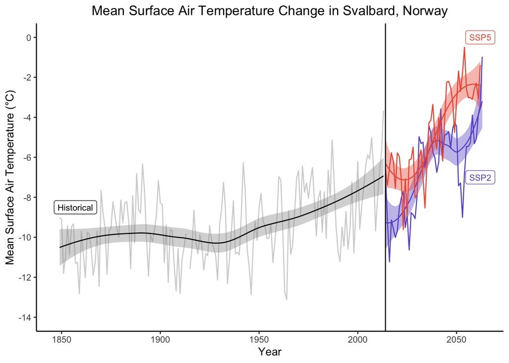

```r
ggplot() +
  geom_line(data = cesm_2_yearly, aes(x = year, y = mean_tas),
            color = "slateblue3") +
  geom_smooth(data = cesm_2_yearly, aes(x = year, y = mean_tas), method = "loess", size = .5, color = "slateblue3", fill = "slateblue3") +
  geom_line(data = cesm_5_yearly, aes(x = year, y = mean_tas),
            color = "tomato2") +
  geom_smooth(data = cesm_5_yearly, aes(x = year, y = mean_tas), method = "loess", size = .5, color = "tomato2", fill = "tomato2") +

  geom_line(data = historical_cesm_yearly, aes(x = year, y = mean_tas),
            color = "lightgray") +
  geom_smooth(data = historical_cesm_yearly, aes(x = year, y = mean_tas), method = "loess", size = .5, color = "black") +

  theme_classic() +
  geom_vline(xintercept = 2014) +
  scale_y_continuous(breaks = seq(from = -14, to = 0, by = 2), limits = c(-14,0)) +
  annotate("label", x = 2062, y = 0, label = "SSP5",color = "tomato2", size = 3)  +
  annotate("label", x = 2062, y = -7, label = "SSP2",color = "slateblue3", size = 3) +
  annotate("label", x = 1857, y = -8.5, label = "Historical",color = "black", size = 3) +
  labs(x = "Year", y ="Mean Surface Air Temperature (°C)", title = "Mean Surface Air Temperature Change in Svalbard, Norway") +
  theme(plot.title = element_text(hjust = 0.5))
```

**Figure 1.** Mean surface air temperature (tas) change in Svalbard, Norway using Community Earth System Models (CESM) to visualize future tas projections under two different emission scenarios. SSP5 is the highest emission scenario of fossil-fueled development, while SSP2 is a middle of the road scenario.

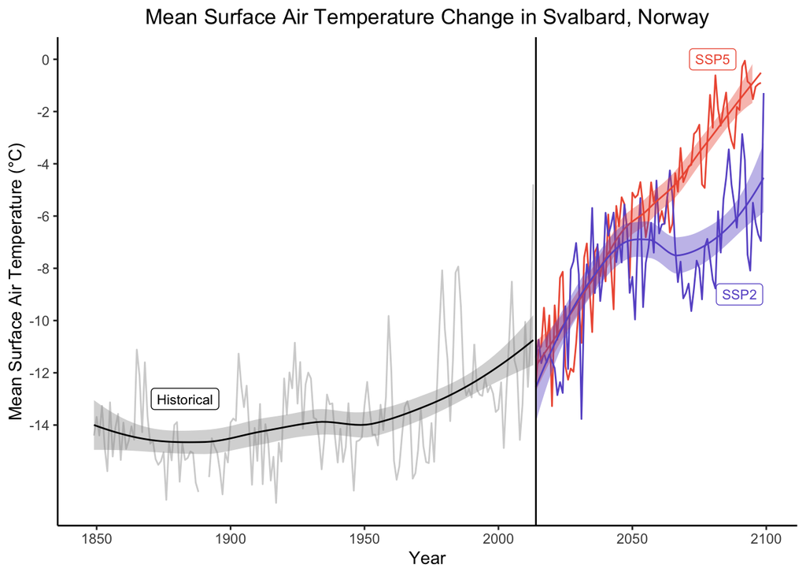

```r
ggplot() +

  geom_line(data = fgoal_5_yearly, aes(x = year, y = mean_tas), color = "tomato2") +
  geom_line(data = fgoal_2_yearly, aes(x = year, y = mean_tas),
            color = "slateblue3") +
  geom_smooth(data = fgoal_5_yearly, aes(x = year, y = mean_tas), method = "loess", size = .5, color = "tomato2", fill = "tomato2") +
   geom_smooth(data = fgoal_2_yearly, aes(x = year, y = mean_tas), method = "loess", size = .5, color = "slateblue3", fill = "slateblue3") +

  geom_line(data = historical_fgoal_yearly, aes(x = year, y = mean_tas),
            color = "lightgray") +
  geom_smooth(data = historical_fgoal_yearly, aes(x = year, y = mean_tas), method = "loess", size = .5, color = "black") +
  annotate("label", x = 2080, y = 0, label = "SSP5",color = "tomato2", size = 3)  +
  annotate("label", x = 2090, y = -9, label = "SSP2",color = "slateblue3", size = 3) +
  annotate("label", x = 1883, y = -13, label = "Historical",color = "black", size = 3) +

  theme_classic() +
  geom_vline(xintercept = 2014) +
  scale_y_continuous(breaks = seq(from = -14, to = 0, by = 2), limits = c(-17,0)) +
  labs(x = "Year", y ="Mean Surface Air Temperature (°C)", title = "Mean Surface Air Temperature Change in Svalbard, Norway") +
  theme(plot.title = element_text(hjust = 0.5))
```

**Figure 2.** Mean surface air temperature (tas) change in Svalbard, Norway using Flexible Global Ocean-Atmosphere-Land System Model (Fgoal) to visualize future tas projections under two different emission scenarios. SSP5 is the highest emission scenario of fossil-fueled development, while SSP2 is a middle of the road scenario.

**Sources:** https://www.carbonbrief.org/explainer-how-shared-socioeconomic-pathways-explore-future-climate-change Descamps et al., 2017 https://doi.org/10.1111/gcb.13381